# Part II - (Prosper Loan)

## by (David Gikandi)

## Investigation Overview

> We will begin with looking at individual features distribution, before diving to look at how they correlate to each other.

> We will looked at the correlation between the loan amount, investors, and the borrower rate. Secondly, the relationship between the employment status and the loan term was investigated.

> Lastly, we will also looked at the relationship between the borrower rate, prosper score, and the income range.

## Dataset Overview

> The dataset cosnsits of 113, 937 atrributes which include; loan amount, borrower rate, loan term, prosper score, investors, employment status, and income range. With more variables that were not utilised in this investigation.

## Borrower Rate Distribution

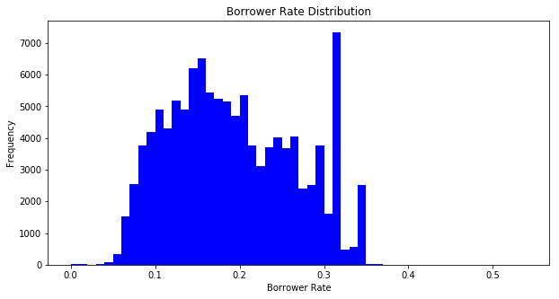

## Borrower rate vs Loan amount vs investors

> The correlatin between the Borrower rate and the loan amount is -0.329. This negative correlation confirms our hypothesis that as the loan amount increases the borrower rate is decreases.

> The correlation between the Investors and the loan amount is 0.380. This implies that as the loan amount increases even more investors will be needed to finance the loan.

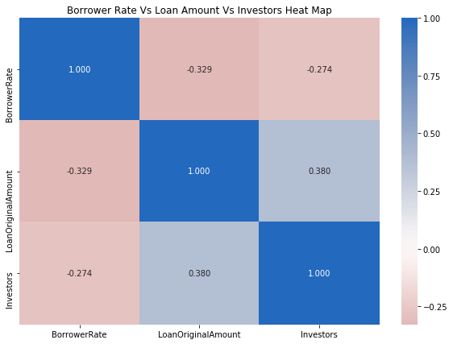

## Employment Status Vs Term

> In every employment status category, the preffered loan term is 36 months. This is followed by the 60 months term. While the 12 months term is the least desirable.

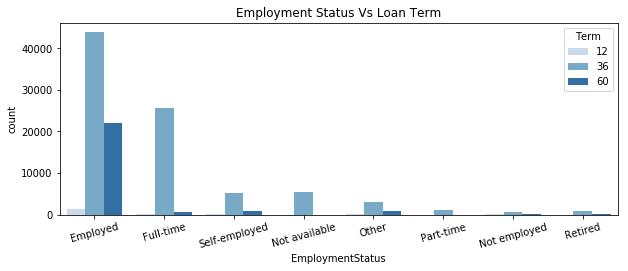

## Borrower rate vs Prosper score vs Income range

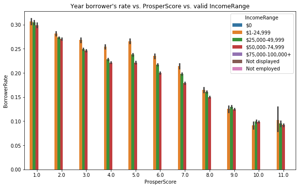